# Prueba T para dos muestras independientes

## El estudio

Entre los criadores de terneros existe una marcada preferencia por la época de parición de las crías. La gran mayoría favorece los nacimientos en invierno para que el período de destete coincida con el inicio de la primavera. Las razones dadas por los criadores son variadas, siendo una de ellas que los terneros nacidos en invierno alcanzan un peso mayor al momento del destete que los nacidos en verano, lo cuál hace que la producción en estas fechas sea más atractiva.

Análogamente, se quiere saber si puede concluirse lo mismo para la cría de potrillos para utilizar en deportes de alto rendimiento. En este caso, tener potrillos más pequeños podría generar una ventaja al momento de seleccionarlos para deportes en los que la agilidad sea un factor importante.

Para ello se obtuvieron datos de 400 nacimientos en criaderos de caballos Cuarto de Milla de Argentina, para el período 2020 - 2021. Los datos se tabularon detallando el peso del potrillo al nacer. A cada potrillo se le asignó un grupo, dependiendo de la estación del año en la que nacieron. La muestra se compone de dos grupos, con 210 potrillos nacidos en verano (grupo1) y 190 en invierno (grupo2).

*Tener en cuenta que todo este contexto es ficticio.*

## Carga de datos

```r
library(dplyr)
library(ggplot2)
```

```r
data <- read.csv("data/datos21.txt", header = FALSE, sep = "\t", col.names = c('weight', 'group'))

head(data)
```

```
##   weight  group
## 1   46.3 grupo1
## 2   48.3 grupo1
## 3   55.1 grupo1
## 4   56.0 grupo1
## 5   46.7 grupo1
## 6   45.5 grupo1
```

## Estadística descriptiva

A continuación se presenta una tabla con medidas resumen, para comenzar a comprender los datos tratados.

```r
data %>% group_by(group) %>%
  summarise(min = min(weight),
            max = max(weight),
            mean = mean(weight),
            sd = sd(weight),
            n = n(),
            q1 = quantile(weight, .25),
            q3 = quantile(weight, .75))
```

```
## # A tibble: 2 × 8
##   group    min   max  mean    sd     n    q1    q3
##   <chr>  <dbl> <dbl> <dbl> <dbl> <int> <dbl> <dbl>
## 1 grupo1  41.5  58.5  50.3  3.01   210  48.1  52.4
## 2 grupo2  52.5  67    60.1  2.99   190  58    62.1
```

Puede observarse que el peso medio en el grupo2 (invierno) es 10 kg mayor que para el grupo1 (verano). Para ambas muestras el valor de la mediana se encuentra próximo al de la media, lo que sugiere que los datos están centrados aproximadamente en sus valores centrales. Las desviaciones estándar son muy similares para ambas muestras, indicando que varían de manera parecida respecto a su media.

POdemos observar lo mismo con el siguiente boxplot.

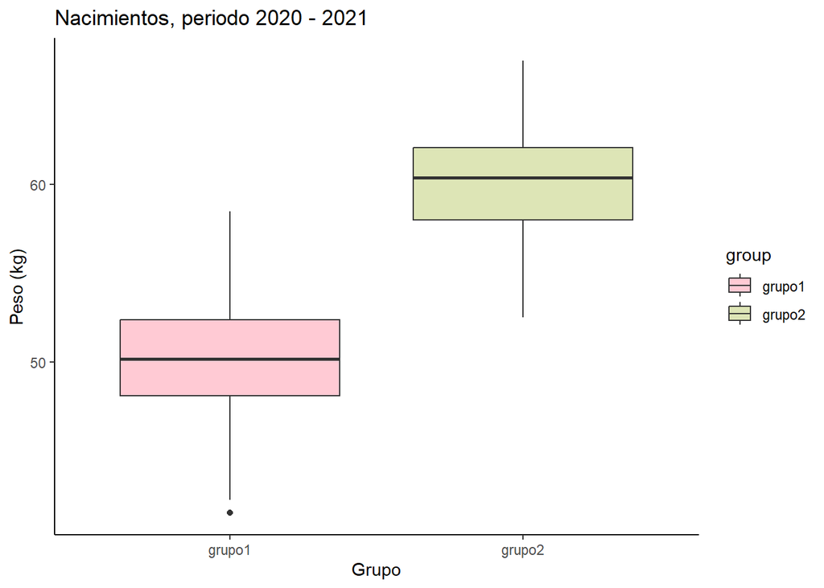

```r
data %>% ggplot(aes(x=group, y=weight, fill=group)) +
  geom_boxplot() +
  scale_fill_manual(values = c("#ffcad4", "#dde5b6")) +
  labs(
    title = "Nacimientos, periodo 2020 - 2021",
    x = "Grupo",
    y = "Peso (kg)"
  ) +
  theme_classic()
```

Aquí podemos notar que en verano se registraron pesos mínimos extremos. Además se hace evidente que los valores mínimos del grupo de potrillos nacidos en invierno se solapan con los máximos de los nacidos en verano.

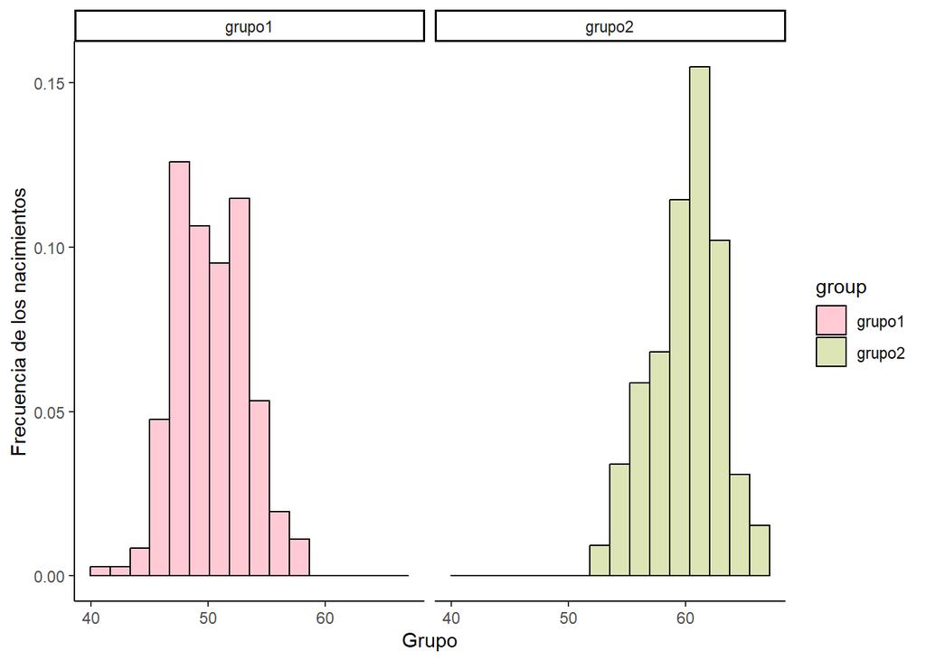

```r
data %>%
  ggplot( aes(x=weight, color=group, fill=group)) +
    geom_histogram(aes(y=after_stat(density)),bins=16, colour = 1) +
    scale_fill_manual(values = c("#ffcad4", "#dde5b6")) +
    xlab("Grupo") +
    ylab("Frecuencia de los nacimientos") +
    facet_wrap(~group) +
    theme_classic()
```

Los histogramas nos permiten ver a simple vista la distribución de los datos.

A la izquierda del gráfico vemos que la muestra de potrillos nacidos en verano es aproximadamente simétrica. A la derecha del mismo gráfico, para potrillos nacidos en invierno, se observa una leve asimetría negativa.

A priori podríamos inferir que hay una tendencia a obtener potrillos más pequeños si nacen a temperaturas más elevadas.

## Hipótesis

Nula: No se observan diferencias en el peso promedio de los potrillos nacidos en diferentes épocas del año. Aquellos nacidos en verano pesan lo mismo que los nacidos en invierno.

$\mu_{V} - \mu_{I} = 0$

Alternativa: Se observan diferencias en el peso promedio de los potrillos nacidos en diferentes épocas del año, siendo los nacidos en verano menos pesados que los nacidos en invierno.

$\mu_{V} - \mu_{I} < 0$

Being

$\mu_{V}$ : Media del peso en kilogramos de los potrillos nacidos en verano

$\mu_{I}$ : Media del peso en kilogramos de los potrillos nacidos en invierno

## Prueba de hipótesis

```r
summer <- filter(data, group == "grupo1") %>% select(weight) %>% unlist
winter <- filter(data, group == "grupo2") %>% select(weight) %>% unlist
```

### Comprobando el supuesto de normalidad

Para dos muestras independientes se asume que las observaciones dentro de cada categoría se distribuyen normalmente.

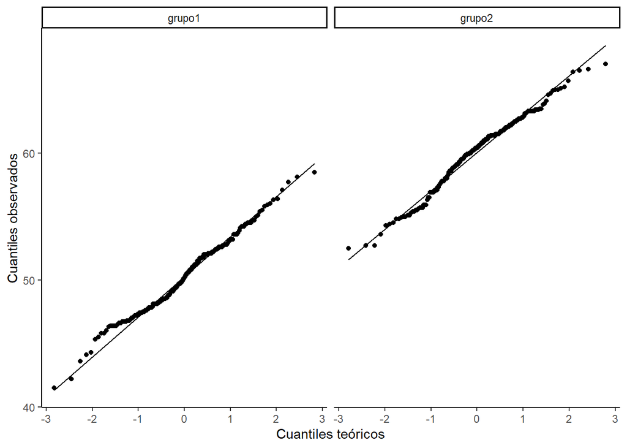

```r
data %>% ggplot(aes(sample = weight)) +
  stat_qq() +
  stat_qq_line() +
  xlab("Cuantiles teóricos") +
  ylab("Cuantiles observados") +
  facet_wrap(~group) +
  theme_classic()
```

ara corroborar que el supuesto se cumpla se realizan los gráficos “q-q normal” de ambas categorías. Se observa que las muestras se ajustan a la distribución normal, mostrando una asociación lineal muy fuerte entre los cuantiles observados y esperados.

### Resultados

```r
t.test(
  x = summer,
  y = winter,
  alternative="less",
  mu = 0,
  paired=FALSE,
  var.equal=TRUE,
  conf.level=0.95
  )
```

```
##
##  Two Sample t-test
##
## data:  summer and winter
## t = -32.573, df = 398, p-value < 2.2e-16
## alternative hypothesis: true difference in means is less than 0
## 95 percent confidence interval:
##       -Inf -9.292307
## sample estimates:
## mean of x mean of y
##  50.28333  60.07105
```

Habiendo obtenido el valor del estadístico de prueba $t=-32.57$ y los grados de libertad $df = 398$, la prueba arrojó un $p-value<0.0001$. Comparándolo con el nivel de significancia aceptado por convención ($\alpha=0.05$) podemos decir que la prueba fue extremadamente significativa y estamos en condiciones de rechazar nuestra hipótesis nula. La muestra, entonces, aporta evidencia significativa de que el peso medio de los potrillos nacidos en verano es menor al peso medio de los nacidos en invierno.

Podemos observar tambien que el intervalo de confienza es significativo y no inclute al cero.

A continuación se muestra un gráfico comparando visualmente las medias de ambas muestras.

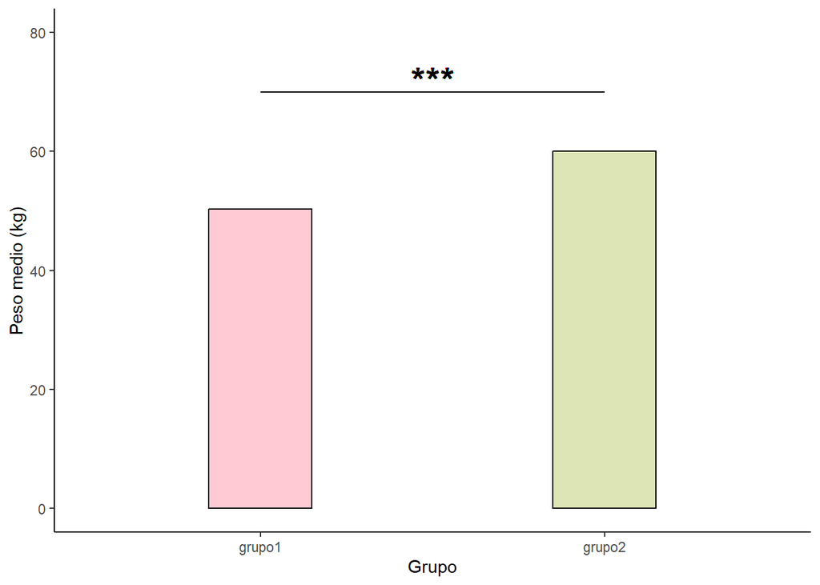

```r
data %>% ggplot(aes(y=weight, x=group)) +
  stat_summary(
    fun = mean,
    geom = "bar",
    color = "black",
    width = .3,
    fill = c("#ffcad4", "#dde5b6")) +
  ylim(0, 80) +
  geom_segment(
    x = 1,
    y = 70,
    xend = 2,
    yend = 70
  ) +
  geom_text(
    x = 1.5,
    y = 72,
    label = "***",
    size = 8
  ) +
  theme_classic() +
  labs(
    x = "Grupo",
    y = "Peso medio (kg)"
  )
```

Ya que se rechaza la hipótesis nula existe la posibilidad de estar cometiendo error de tipo I, concluir que el peso medio en verano es menor que en invierno, habiendo en realidad obtenido este resultado por azar. Sin embargo, la probabilidad de cometer este error es muy baja, menor al 0,0001.

## Conclusión

Podemos concluir que para producir caballos más pequeños para ser utilizados en deportes de agilidad se deberían favorecer los nacimientos en verano ya que se observa una tendencia a obtener pesos menores en el periodo estival.